# tidyr

The tidyr package includes functions to transfer a data frame between long and wide formats. In the section on tidy data, we showed an example that used gather to convert data into a tidy format. The data is first in an untidy format:

```r
data("VADeaths")
class(VADeaths)
```

```
## [1] "matrix"
```

```r
head(VADeaths)
```

```
##       Rural Male Rural Female Urban Male Urban Female
## 50-54       11.7          8.7       15.4          8.4
## 55-59       18.1         11.7       24.3         13.6
## 60-64       26.9         20.3       37.0         19.3
## 65-69       41.0         30.9       54.6         35.1
## 70-74       66.0         54.3       71.1         50.0
```

After changing the age categories from row names to a variable (which can be done with the mutate function), the key problem with the tidyness of the data is that the variables of urban / rural and male / female are not in their own columns, but rather are embedded in the structure of the columns. To fix this, you can use the gather function to gather values spread across several columns into a single column, with the column names gathered into a “key” column. When gathering, exclude any columns that you don’t want “gathered” (age in this case) by including the column names with a the minus sign in the gather function. For example:

```r
library(tidyr)
library(dplyr)#requireed for tbl_df
# Move age from row names into a column
VADeaths  <- VADeaths %>% tbl_df() %>% mutate(age = row.names(VADeaths))
VADeaths
```

```
## # A tibble: 5 × 5
##   `Rural Male` `Rural Female` `Urban Male` `Urban Female`   age
##          <dbl>          <dbl>        <dbl>          <dbl> <chr>
## 1         11.7            8.7         15.4            8.4 50-54
## 2         18.1           11.7         24.3           13.6 55-59
## 3         26.9           20.3         37.0           19.3 60-64
## 4         41.0           30.9         54.6           35.1 65-69
## 5         66.0           54.3         71.1           50.0 70-74
```

```r
# Gather everything but age to tidy data
VADeaths %>% gather(key = key, value = death_rate, -age)
```

```
## # A tibble: 20 × 3
##      age          key death_rate
##    <chr>        <chr>      <dbl>
## 1  50-54   Rural Male       11.7
## 2  55-59   Rural Male       18.1
## 3  60-64   Rural Male       26.9
## 4  65-69   Rural Male       41.0
## 5  70-74   Rural Male       66.0
## 6  50-54 Rural Female        8.7
## 7  55-59 Rural Female       11.7
## 8  60-64 Rural Female       20.3
## 9  65-69 Rural Female       30.9
## 10 70-74 Rural Female       54.3
## 11 50-54   Urban Male       15.4
## 12 55-59   Urban Male       24.3
## 13 60-64   Urban Male       37.0
## 14 65-69   Urban Male       54.6
## 15 70-74   Urban Male       71.1
## 16 50-54 Urban Female        8.4
## 17 55-59 Urban Female       13.6
## 18 60-64 Urban Female       19.3
## 19 65-69 Urban Female       35.1
## 20 70-74 Urban Female       50.0
```

Even if your data is in a tidy format, gather is occasionally useful for pulling data together to take advantage of faceting, or plotting separate plots based on a grouping variable. For example, if you’d like to plot the relationship between the time a player played in the World Cup and his number of saves, tackles, and shots, with a separate graph for each position (Figure 1.2), you can use gather to pull all the numbers of saves, tackles, and shots into a single column (Number) and then use faceting to plot them as separate graphs:

```r
library(ggplot2)
library(faraway)
data(worldcup)

worldcup %>% select(Position, Time, Shots, Tackles, Saves) %>%  head()
```

```
##              Position Time Shots Tackles Saves
## Abdoun     Midfielder   16     0       0     0
## Abe        Midfielder  351     0      14     0
## Abidal       Defender  180     0       6     0
## Abou Diaby Midfielder  270     1       5     0
## Aboubakar     Forward   46     2       0     0
## Abreu         Forward   72     0       0     0
```

```r
worldcup %>% select(Position, Time, Shots, Tackles, Saves) %>%  gather(key=Type, Number, -Position, -Time) %>% head()
```

```
##     Position Time  Type Number
## 1 Midfielder   16 Shots      0
## 2 Midfielder  351 Shots      0
## 3   Defender  180 Shots      0
## 4 Midfielder  270 Shots      1
## 5    Forward   46 Shots      2
## 6    Forward   72 Shots      0
```

```r
glimpse(worldcup)
```

```
## Observations: 595
## Variables: 7
## $ Team     <fctr> Algeria, Japan, France, France, Cameroon, Uruguay, G...
## $ Position <fctr> Midfielder, Midfielder, Defender, Midfielder, Forwar...
## $ Time     <int> 16, 351, 180, 270, 46, 72, 138, 33, 21, 103, 270, 55,...
## $ Shots    <int> 0, 0, 0, 1, 2, 0, 0, 0, 5, 0, 2, 0, 2, 1, 1, 1, 5, 9,...
## $ Passes   <int> 6, 101, 91, 111, 16, 15, 51, 9, 22, 38, 120, 31, 57, ...
## $ Tackles  <int> 0, 14, 6, 5, 0, 0, 2, 0, 0, 1, 10, 2, 2, 11, 13, 7, 3...
## $ Saves    <int> 0, 0, 0, 0, 0, 0, 0, 0, 0, 0, 0, 0, 0, 0, 0, 0, 0, 0,...
```

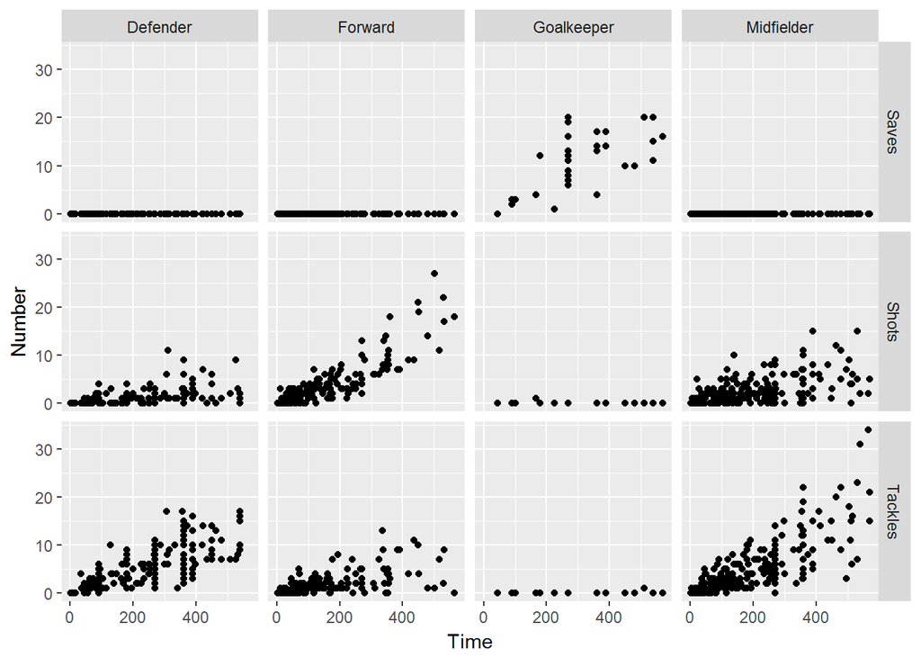

```r
worldcup %>%
  select(Position, Time, Shots, Tackles, Saves) %>%  gather(key=Type, Number, -Position, -Time) %>%
  ggplot(aes(x = Time, y = Number)) + geom_point() + facet_grid(Type ~ Position)
```

Figure 1.2: Example of a faceted plot created by taking advantage of the gather function to pull together data.

The spread function is less commonly needed to tidy data. It can, however, be useful for creating summary tables. For example, if you wanted to print a table of the average number and range of passes by position for the top four teams in this World Cup (Spain, Netherlands, Uruguay, and Germany), you could run:

```r
library(knitr)

# Summarize the data to create the summary statistics you want
wc_table <- worldcup %>%
  filter(Team %in% c("Spain", "Netherlands", "Uruguay", "Germany")) %>%
  select(Team, Position, Passes) %>%
  group_by(Team, Position) %>%
  summarize(ave_passes = mean(Passes), min_passes = min(Passes), max_passes = max(Passes),
            pass_summary = paste0(round(ave_passes), " (", min_passes, ", ", max_passes, ")")) %>%
  select(Team, Position, pass_summary)
# What the data looks like before using `spread`
wc_table
```

```
## Source: local data frame [16 x 3]
## Groups: Team [4]
##
##           Team   Position   pass_summary
##         <fctr>     <fctr>          <chr>
## 1      Germany   Defender  190 (44, 360)
## 2      Germany    Forward    90 (5, 217)
## 3      Germany Goalkeeper    99 (99, 99)
## 4      Germany Midfielder   177 (6, 423)
## 5  Netherlands   Defender  182 (30, 271)
## 6  Netherlands    Forward   97 (12, 248)
## 7  Netherlands Goalkeeper 149 (149, 149)
## 8  Netherlands Midfielder  170 (22, 307)
## 9        Spain   Defender   213 (1, 402)
## 10       Spain    Forward   77 (12, 169)
## 11       Spain Goalkeeper    67 (67, 67)
## 12       Spain Midfielder  212 (16, 563)
## 13     Uruguay   Defender   83 (22, 141)
## 14     Uruguay    Forward   100 (5, 202)
## 15     Uruguay Goalkeeper    75 (75, 75)
## 16     Uruguay Midfielder   100 (1, 252)
```

```r
# Use spread to create a prettier format for a table
wc_table %>% spread(Position, pass_summary) %>% kable()
```

| Team | Defender | Forward | Goalkeeper | Midfielder |
| --- | --- | --- | --- | --- |
| Germany | 190 (44, 360) | 90 (5, 217) | 99 (99, 99) | 177 (6, 423) |
| Netherlands | 182 (30, 271) | 97 (12, 248) | 149 (149, 149) | 170 (22, 307) |
| Spain | 213 (1, 402) | 77 (12, 169) | 67 (67, 67) | 212 (16, 563) |
| Uruguay | 83 (22, 141) | 100 (5, 202) | 75 (75, 75) | 100 (1, 252) |

Notice in this example how spread has been used at the very end of the code sequence to convert the summarized data into a shape that offers a better tabular presentation for a report. In the spread call, you first specify the name of the column to use for the new column names (Position in this example) and then specify the column to use for the cell values (pass_summary here).

In this code, I’ve used the kable function from the knitr package to create the summary table in a table format, rather than as basic R output. This function is very useful for formatting basic tables in R markdown documents. For more complex tables, check out the pander and xtable packages.